# Heart_Disease_Analysis

Surendar | Vyshnavi (Project Team 11)

2025-03-26

## Dataset Background

This heart disease dataset contains **10,000 observations** and **21 variables**. This dataset includes:

**Demographic variables**: Age and Gender

**Vital Measurement**: Blood Pressure, Cholesterol Levels, BMI

**Lifestyle factors**: Exercise Habits, Smoking, Alcohol Consumption, Sleep Hours

**Medical history**: Family Heart Disease, Diabetes

**Biomarkers**: Triglyceride Level, Fasting Blood Sugar, CRP Level, Homocysteine Level

**Diagnostic Indicators**: Heart Disease Status

**Cholesterol -> Identified as Response Variable** because of its relationship with heart health outcomes. So predict cholesterol level using the linear regression model.

1. Heart disease in one of the leading cause of deaths worldwide
2. A direct measurement to be considered for cardiovascular risk
3. Also, serves as one of the primary factor doctors recommend to get in control for heart disease prevention
4. It is responsive to both lifestyle factors and medications
5. Data Collection and data cleaning **Import the heart_disease dataset**

```r
library(tidyverse)
heart_disease_data<-read.csv("data/heart_disease.csv")
```

**Initial Dataset - Summary**

```r
initial_dataset_dim<-dim(heart_disease_data)
initial_data_row_count<-initial_dataset_dim[1]
initial_data_column_count<-initial_dataset_dim[2]
cat("Number of rows = ", initial_data_row_count, "\n")
```

```
## Number of rows =  10000
```

```r
cat("Number of columns = ", initial_data_column_count, "\n")
```

```
## Number of columns =  21
```

```r
# str(heart_disease_data)
# head(heart_disease_data, 10)
# summary(heart_disease_data)
```

**Total number of columns that has missing values with their names**

```r
#=================================================================================
#Numerical Columns
#=================================================================================
missing_values<-colSums(is.na(heart_disease_data))
#print(missing_values)
missing_value_column_names<- names(missing_values[missing_values>0])
cat("Missing value Columns that works with is.na(){numerical columns}:\n")
```

```
## Missing value Columns that works with is.na(){numerical columns}:
```

```r
count_missing_value_columns=1
for(i in missing_value_column_names)
{
  cat(count_missing_value_columns,")",i, ":", missing_values[i],"\n")
  count_missing_value_columns = count_missing_value_columns + 1
}
```

```
## 1 ) Age : 29
## 2 ) Blood.Pressure : 19
## 3 ) Cholesterol.Level : 30
## 4 ) BMI : 22
## 5 ) Sleep.Hours : 25
## 6 ) Triglyceride.Level : 26
## 7 ) Fasting.Blood.Sugar : 22
## 8 ) CRP.Level : 26
## 9 ) Homocysteine.Level : 20
```

```r
total_missing_value_columns<-sum(missing_values>0)
cat("Total columns with missing values (numerical) ->", total_missing_value_columns,"\n")
```

```
## Total columns with missing values (numerical) -> 9
```

```r
#===================================================================================
#Categorical Columns
#===================================================================================
#using na.rm=TRUE to ignore the already accounted NA results when adding up TRUE values
blank_records<- colSums(heart_disease_data=="" | heart_disease_data==" ",na.rm=TRUE)
#print(blank_records)
blank_records_column_names<- names(blank_records[blank_records>0])
cat("\nBlank String Columns that didn't work with is.na(){categorical columns}:\n")
```

```
##
## Blank String Columns that didn't work with is.na(){categorical columns}:
```

```r
count_blank_record_columns=1
for(j in blank_records_column_names)
{
  count_blank_records<- sum(heart_disease_data[[j]]=="" | heart_disease_data[[j]]==" ",na.rm=TRUE)
  cat(count_blank_record_columns, ")",j, ":", count_blank_records, "\n")
  count_blank_record_columns = count_blank_record_columns + 1
  #Assigning NA to those found blank values
  #dataframe[[columnName]][condition]<- NA
  heart_disease_data[[j]][heart_disease_data[[j]]==""|heart_disease_data[[j]]==" "]<- NA
}
```

```
## 1 ) Gender : 19
## 2 ) Exercise.Habits : 25
## 3 ) Smoking : 25
## 4 ) Family.Heart.Disease : 21
## 5 ) Diabetes : 30
## 6 ) High.Blood.Pressure : 26
## 7 ) Low.HDL.Cholesterol : 25
## 8 ) High.LDL.Cholesterol : 26
## 9 ) Alcohol.Consumption : 32
## 10 ) Stress.Level : 22
## 11 ) Sugar.Consumption : 30
```

```r
total_blank_record_columns<-sum(blank_records>0)
cat("Total columns with blank values (categorical) ->", total_blank_record_columns,"\n")
```

```
## Total columns with blank values (categorical) -> 11
```

```r
#====================================================================================
#Total missing = na + blank/empty strings [Numerical + Categorical]
#====================================================================================
missing_values_new<- colSums(is.na(heart_disease_data))
cat("\nMissing values after converting blank records to NA\n")
```

```
##
## Missing values after converting blank records to NA
```

```r
total_blank_record_columns<-sum(missing_values_new>0)
cat("Total columns with both na and blank values (Categorical + Numerical) -> ", total_blank_record_columns,"\n")
```

```
## Total columns with both na and blank values (Categorical + Numerical) ->  20
```

```r
print(missing_values_new)
```

```
##                  Age               Gender       Blood.Pressure
##                   29                   19                   19
##    Cholesterol.Level      Exercise.Habits              Smoking
##                   30                   25                   25
## Family.Heart.Disease             Diabetes                  BMI
##                   21                   30                   22
##  High.Blood.Pressure  Low.HDL.Cholesterol High.LDL.Cholesterol
##                   26                   25                   26
##  Alcohol.Consumption         Stress.Level          Sleep.Hours
##                   32                   22                   25
##    Sugar.Consumption   Triglyceride.Level  Fasting.Blood.Sugar
##                   30                   26                   22
##            CRP.Level   Homocysteine.Level Heart.Disease.Status
##                   26                   20                    0
```

**Total number of columns that don’t have missing values and their names**

```r
total_missing_na_blank<- missing_values + missing_values_new
total_non_missing_na_blank_columns<-sum(total_missing_na_blank==0)

cat("Total Columns not having any missing values -> ", total_non_missing_na_blank_columns,"\n")
```

```
## Total Columns not having any missing values ->  1
```

```r
count_non_na_blank_columns=1
no_missing_value_column_names<- names(total_missing_na_blank[total_missing_na_blank==0])
#print(no_missing_value_column_names)
cat("Columns with No Missing value :\n")
```

```
## Columns with No Missing value :
```

```r
for(k in no_missing_value_column_names)
{
  cat(count_non_na_blank_columns,")", k, "\n")
  count_non_na_blank_columns = count_non_na_blank_columns + 1
}
```

```
## 1 ) Heart.Disease.Status
```

**Cleaning the data - removing missing values from the dataset and calculating the total rows**

```r
cleaned_heart_disease_data<-na.omit(heart_disease_data)
cleaned_dataset_dim<-dim(cleaned_heart_disease_data)
clean_data_row_count<-cleaned_dataset_dim[1]
clean_data_column_count<-cleaned_dataset_dim[2]

Total_removed_rows<-initial_data_row_count-clean_data_row_count
Removed_Rows_Percentage<-(Total_removed_rows/initial_data_row_count)*100
```

**Cleaned Dataset - Summary**

```r
cat("Original dataset: ", initial_data_row_count, "rows and ", initial_data_column_count, "columns\n")
```

```
## Original dataset:  10000 rows and  21 columns
```

```r
cat("Cleaned dataset: ", clean_data_row_count, "rows and ", clean_data_column_count, "columns\n")
```

```
## Cleaned dataset:  9500 rows and  21 columns
```

```r
cat("Total number of removed rows:", Total_removed_rows)
```

```
## Total number of removed rows: 500
```

**Converting categorical variables to factors**

```r
# identifying all the categorical variables and pushing them into a variable
colnames(cleaned_heart_disease_data)
```

```
##  [1] "Age"                  "Gender"               "Blood.Pressure"
##  [4] "Cholesterol.Level"    "Exercise.Habits"      "Smoking"
##  [7] "Family.Heart.Disease" "Diabetes"             "BMI"
## [10] "High.Blood.Pressure"  "Low.HDL.Cholesterol"  "High.LDL.Cholesterol"
## [13] "Alcohol.Consumption"  "Stress.Level"         "Sleep.Hours"
## [16] "Sugar.Consumption"    "Triglyceride.Level"   "Fasting.Blood.Sugar"
## [19] "CRP.Level"            "Homocysteine.Level"   "Heart.Disease.Status"
```

```r
categorical_variables<- c("Gender", "Exercise.Habits", "Smoking", "Family.Heart.Disease", "Diabetes", "High.Blood.Pressure", "Low.HDL.Cholesterol", "High.LDL.Cholesterol", "Alcohol.Consumption", "Stress.Level", "Sugar.Consumption", "Heart.Disease.Status")

# converting the newly created vector variable to factors
cleaned_heart_disease_data[categorical_variables]<- lapply(cleaned_heart_disease_data[categorical_variables],as.factor)
str(cleaned_heart_disease_data[categorical_variables])
```

```
## 'data.frame':    9500 obs. of  12 variables:
##  $ Gender              : Factor w/ 2 levels "Female","Male": 1 2 1 2 2 1 1 2 1 1 ...
##  $ Exercise.Habits     : Factor w/ 3 levels "High","Low","Medium": 1 2 1 2 2 1 2 2 1 1 ...
##  $ Smoking             : Factor w/ 2 levels "No","Yes": 1 1 2 2 2 2 2 2 1 2 ...
##  $ Family.Heart.Disease: Factor w/ 2 levels "No","Yes": 2 1 2 2 1 2 2 2 2 1 ...
##  $ Diabetes            : Factor w/ 2 levels "No","Yes": 2 1 1 2 1 2 2 1 2 2 ...
##  $ High.Blood.Pressure : Factor w/ 2 levels "No","Yes": 1 1 2 2 1 1 1 1 1 1 ...
##  $ Low.HDL.Cholesterol : Factor w/ 2 levels "No","Yes": 2 2 1 1 1 2 1 1 1 1 ...
##  $ High.LDL.Cholesterol: Factor w/ 2 levels "No","Yes": 1 2 2 1 1 1 1 2 1 2 ...
##  $ Alcohol.Consumption : Factor w/ 4 levels "High","Low","Medium",..: 3 2 2 2 2 3 2 2 4 3 ...
##  $ Stress.Level        : Factor w/ 3 levels "High","Low","Medium": 1 2 1 1 3 3 3 3 3 2 ...
##  $ Sugar.Consumption   : Factor w/ 3 levels "High","Low","Medium": 3 2 1 1 2 3 1 1 3 2 ...
##  $ Heart.Disease.Status: Factor w/ 2 levels "No","Yes": 1 1 1 1 1 1 1 1 1 1 ...
```

**Distribution of Categorical Variables**

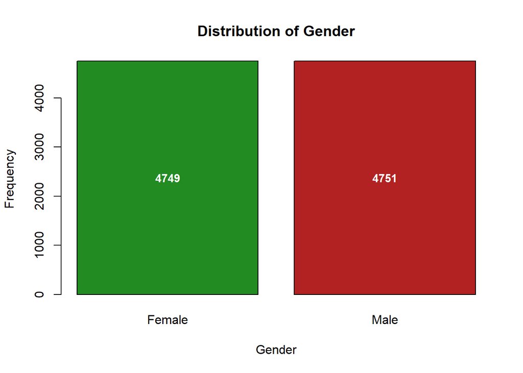

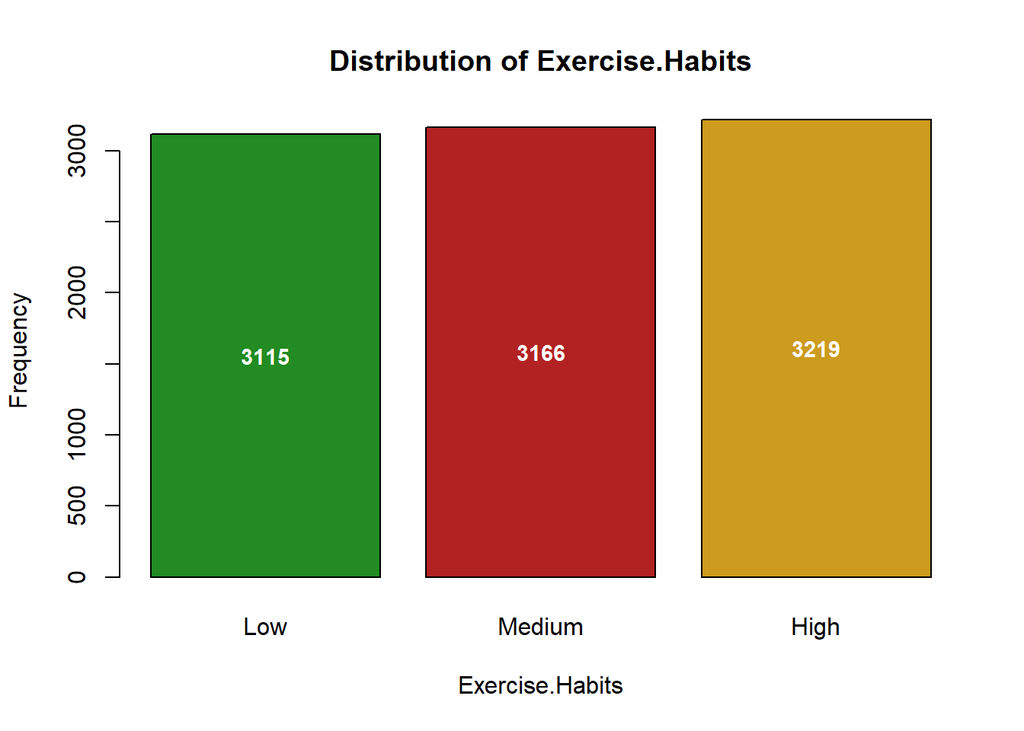

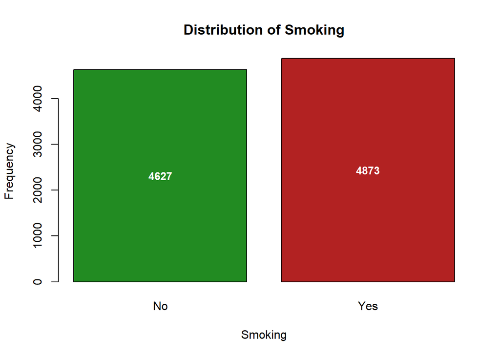

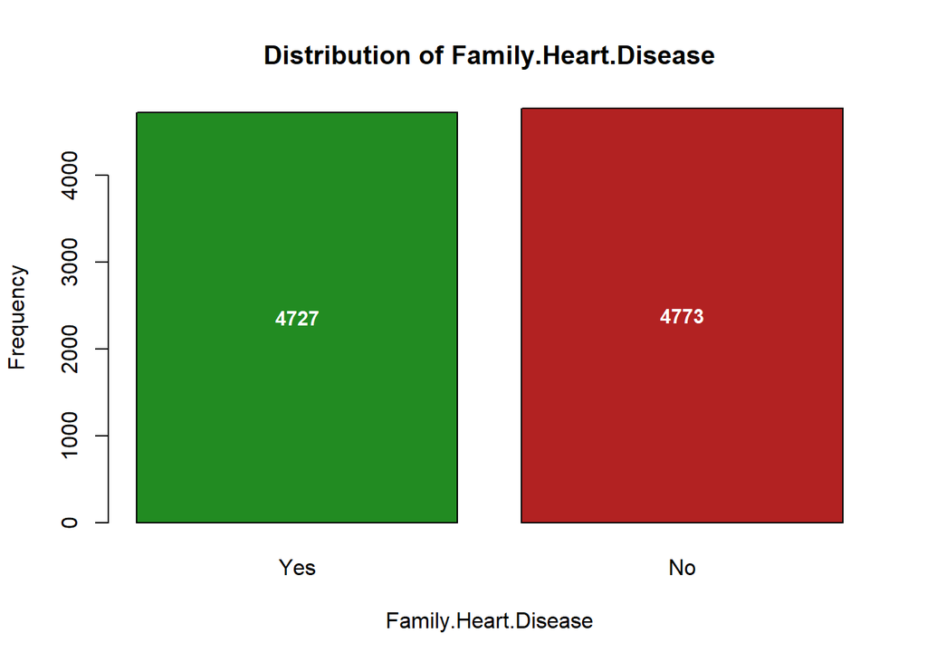

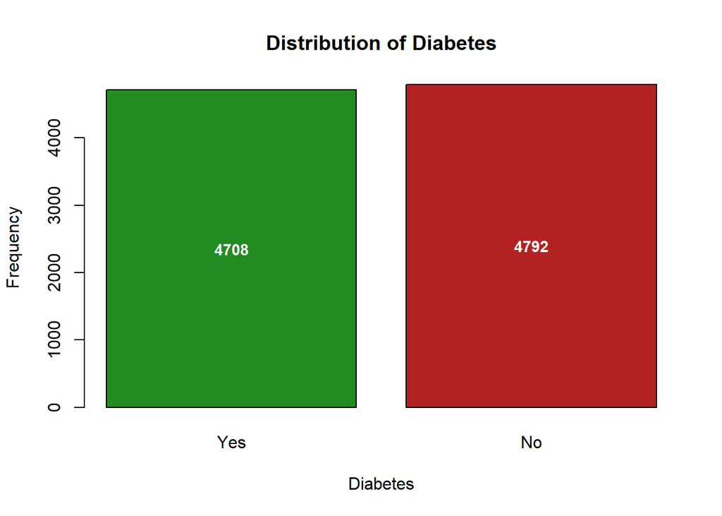

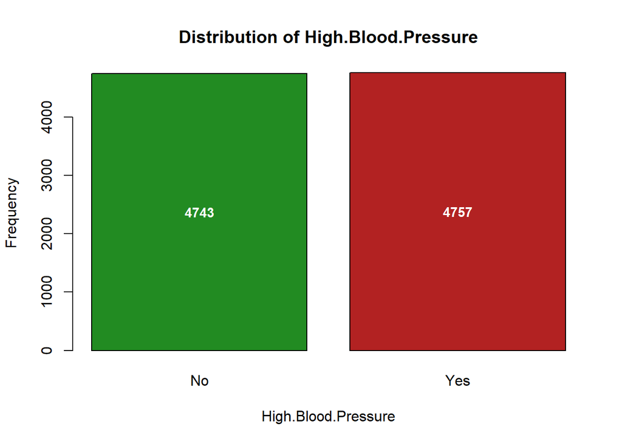

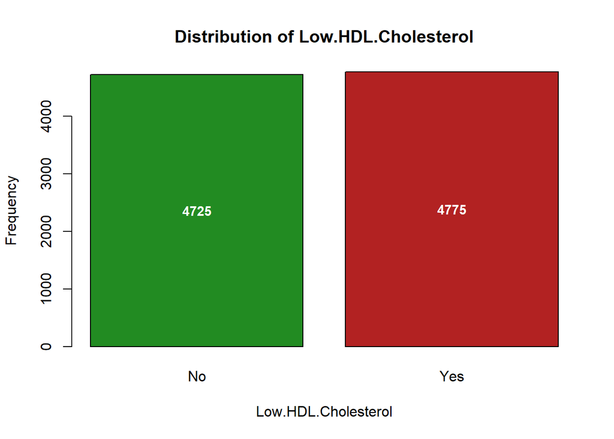

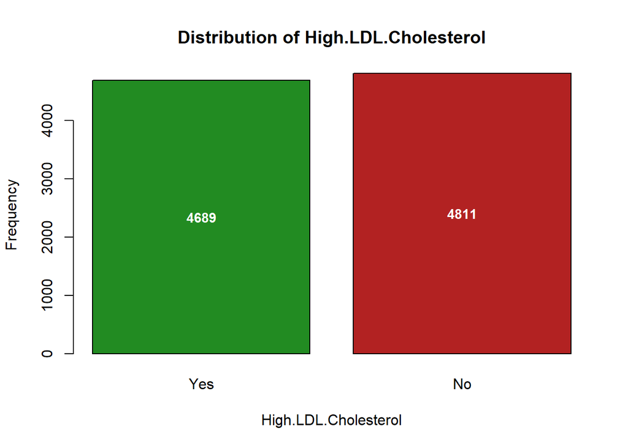

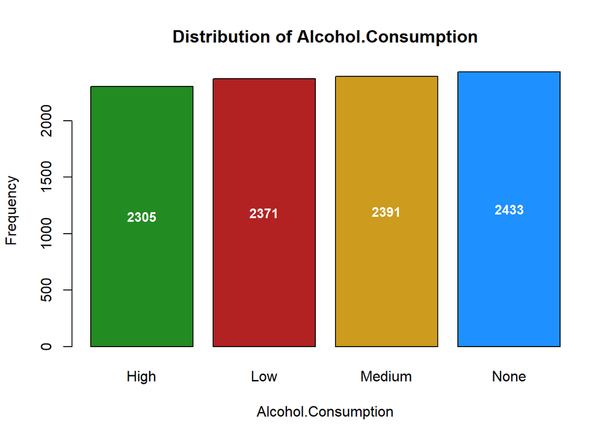

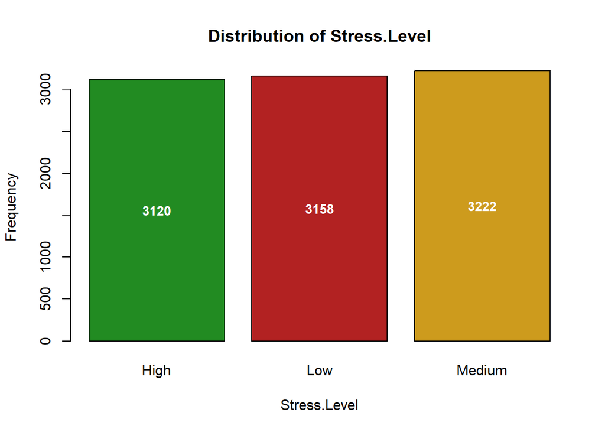

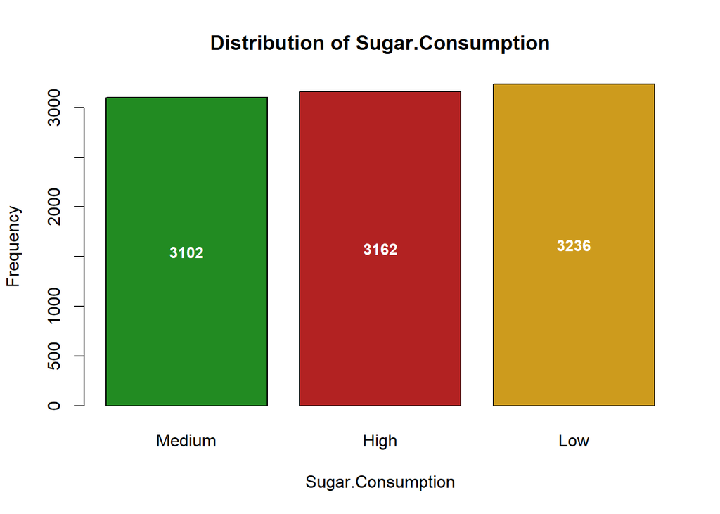

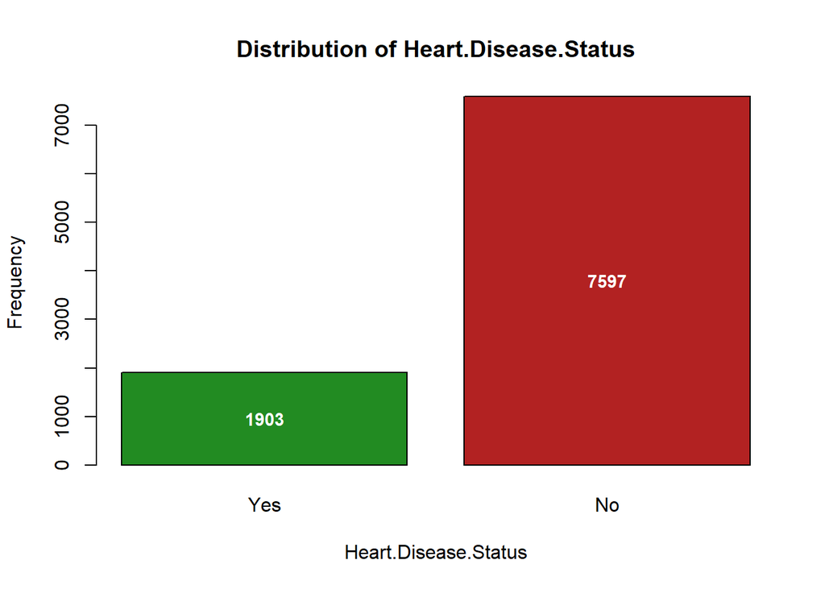

```r
numerical_variables<- c("Age", "Blood.Pressure", "Cholesterol.Level", "BMI", "Sleep.Hours","Triglyceride.Level", "Fasting.Blood.Sugar", "CRP.Level", "Homocysteine.Level")
for(var in categorical_variables){
  count_variables<- table(cleaned_heart_disease_data[[var]])
  sorted_count_variables<- sort(count_variables)
  bar_colors<-c("forestgreen", "firebrick","goldenrod3", "dodgerblue", "slateblue")
  bar_positions<- barplot(sorted_count_variables, main=paste("Distribution of", var), xlab=var, ylab="Frequency", col=bar_colors)
  text(x=bar_positions, y=sorted_count_variables/2, labels=sorted_count_variables, col="white", cex=0.9, font=2)
}
```

**Outliers in Numerical Variables**

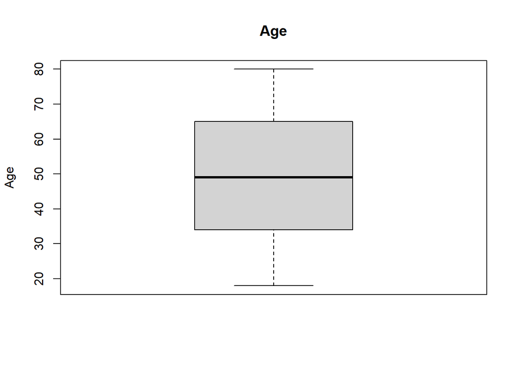

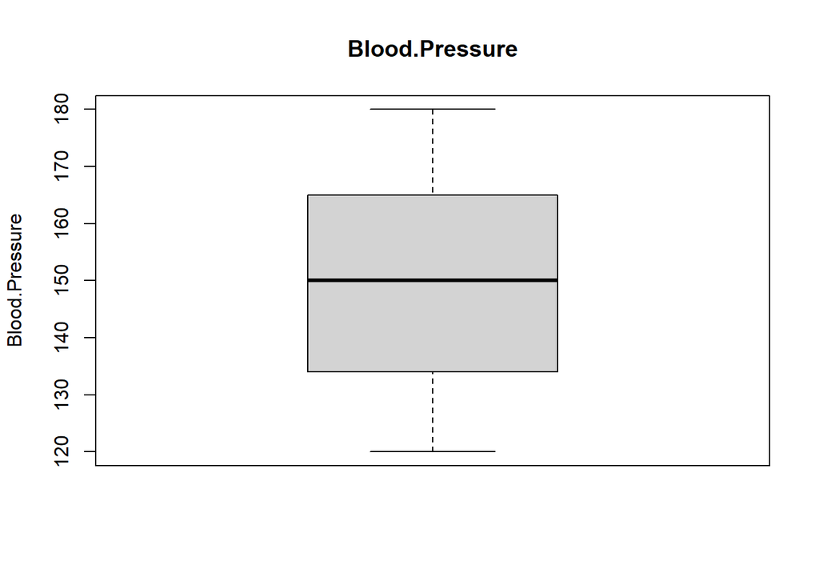

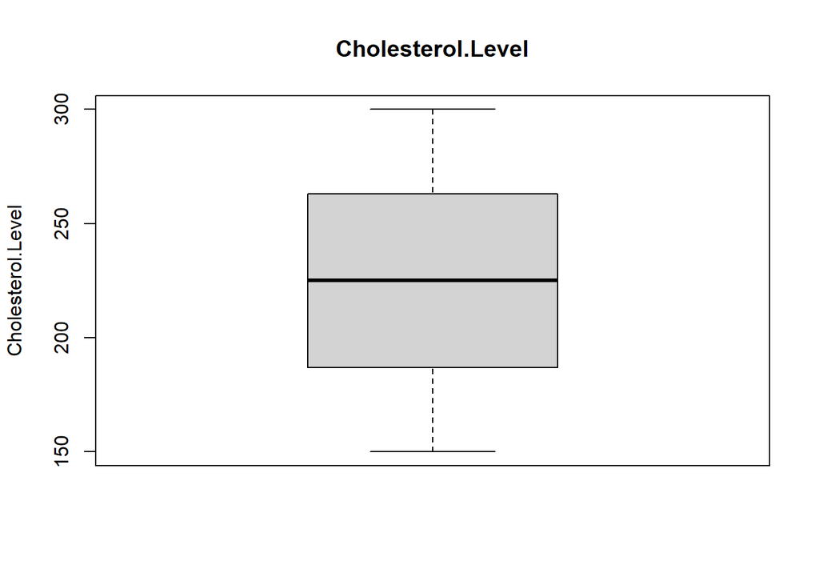

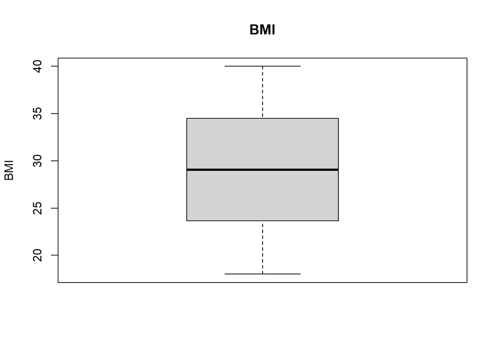

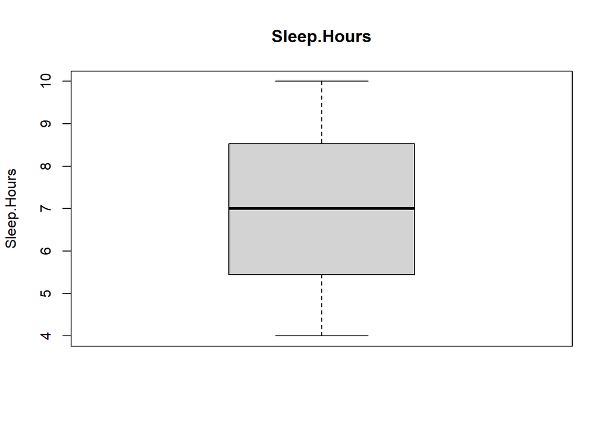

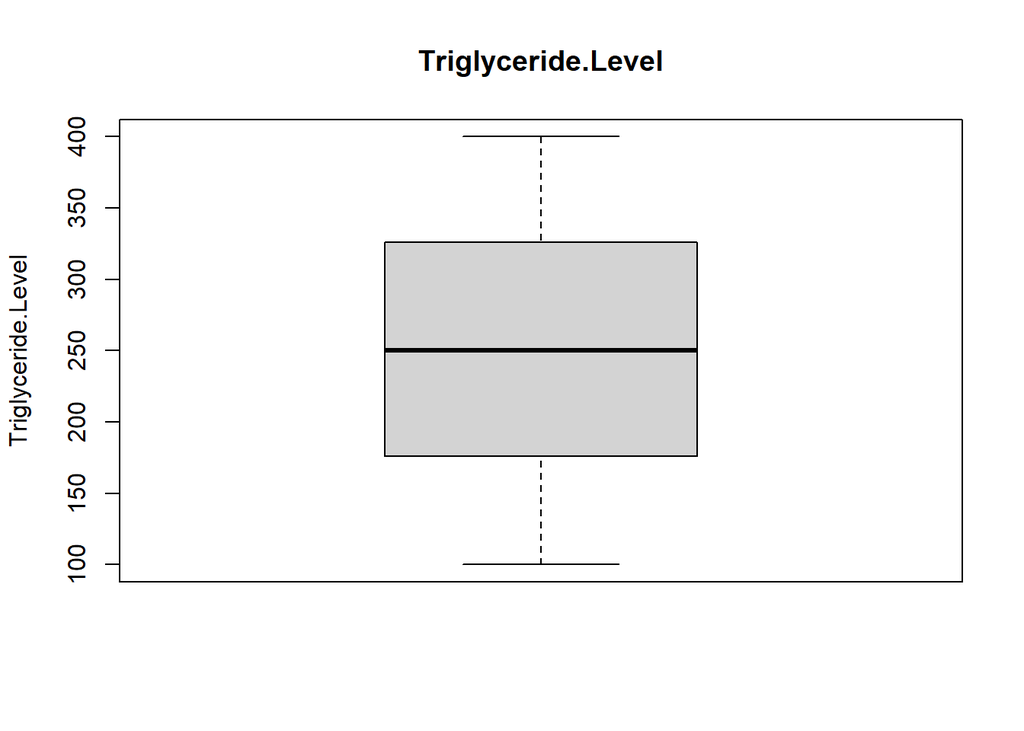

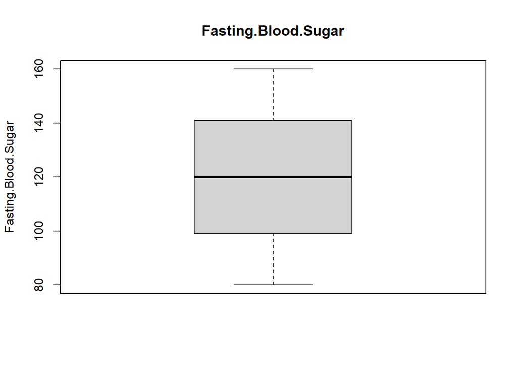

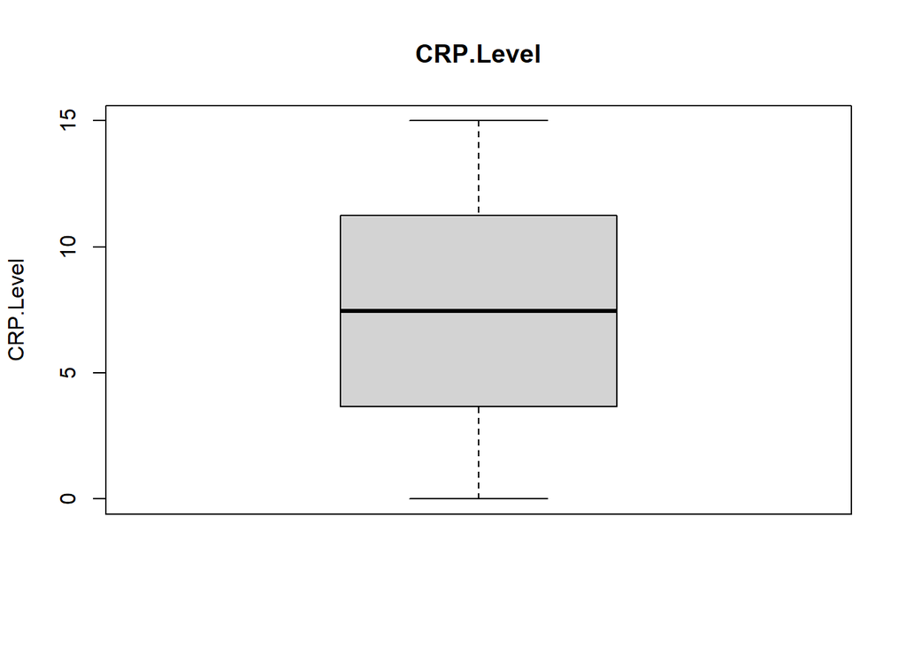

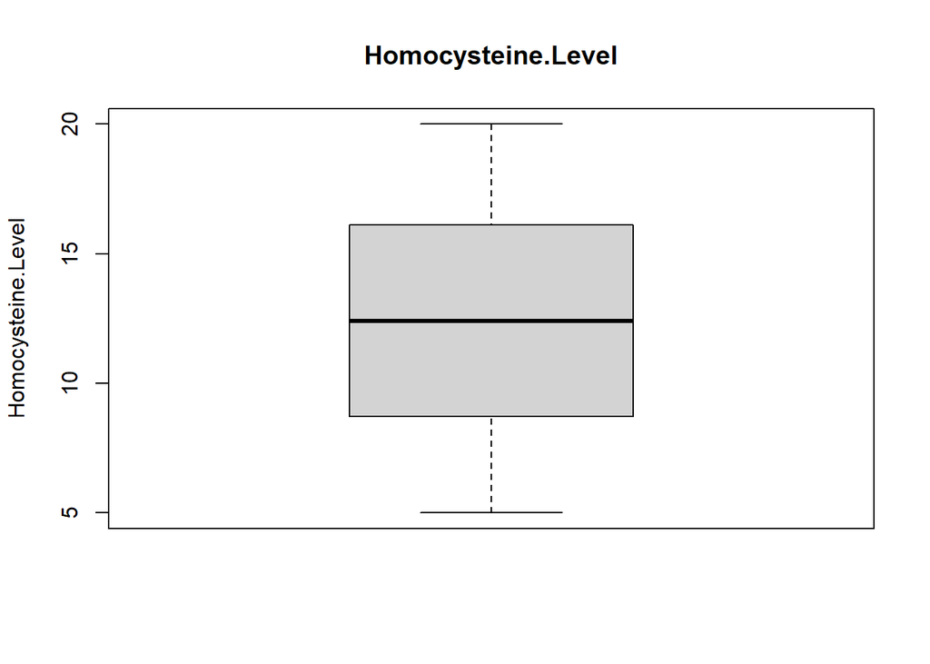

```r
for(var in numerical_variables){
  boxplot(cleaned_heart_disease_data[[var]], main=var, ylab=var)
}
```

2. EDA

```r
cat("Statistical Summary for Cholesterol Level\n")
```

```
## Statistical Summary for Cholesterol Level
```

```r
cholesterol_summary<- summary(cleaned_heart_disease_data$Cholesterol.Level)
print(cholesterol_summary)
```

```
##    Min. 1st Qu.  Median    Mean 3rd Qu.    Max.
##   150.0   187.0   225.0   225.3   263.0   300.0
```

```r
cholesterol_sd<- sd(cleaned_heart_disease_data$Cholesterol.Level)
cat("Standard Deviation - ", round(cholesterol_sd,2),"\n")
```

```
## Standard Deviation -  43.61
```

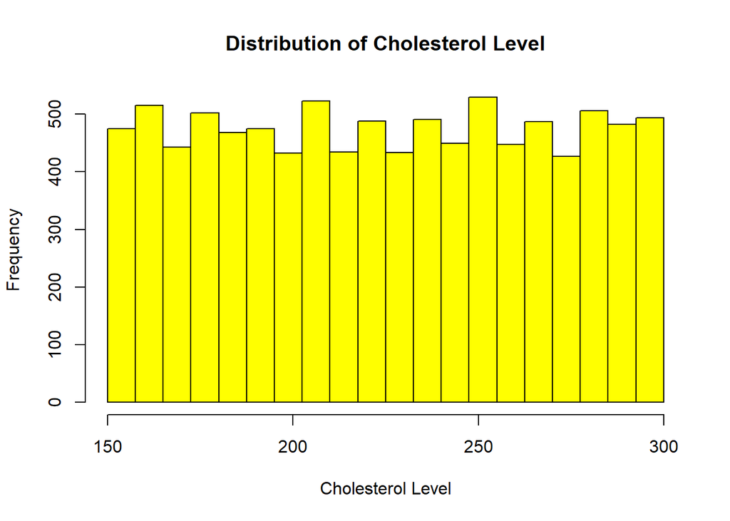

```r
hist(cleaned_heart_disease_data$Cholesterol.Level, main="Distribution of Cholesterol Level", xlab="Cholesterol Level", col="yellow", breaks=seq(min(cleaned_heart_disease_data$Cholesterol.Level),max(cleaned_heart_disease_data$Cholesterol.Level),l=21))
```

```r
#Cholesterol Categories
cholesterol_levels<- c("Desirable", "Borderline High", "High")
#print(length(cholesterol_levels))
cholesterol_bins<- c(0,200,240,Inf)
cholesterol_categories<- cut(cleaned_heart_disease_data$Cholesterol.Level, breaks=cholesterol_bins, labels= cholesterol_levels)
cholesterol_count<- table(cholesterol_categories)
#print(cholesterol_categories)
#cat("Number of people in each cholesterol category",table(cholesterol_categories))
#print(sum(table(cholesterol_categories)))
cholesterol_percent<- (round((table(cholesterol_categories))/sum(table(cholesterol_categories))*100, 1))
#cat(" % of people in each cholesterol category",cholesterol_percent)

cat("\nCholesterol Categories\n")
```

```
##
## Cholesterol Categories
```

```r
for(category in names(table(cholesterol_levels))){
  count<- table(cholesterol_categories)[category]
  percent<- cholesterol_percent[category]
  cat(category, ":", count , "people (", percent, "%)\n")
}
```

```
## Borderline High : 2484 people ( 26.1 %)
## Desirable : 3195 people ( 33.6 %)
## High : 3821 people ( 40.2 %)
```

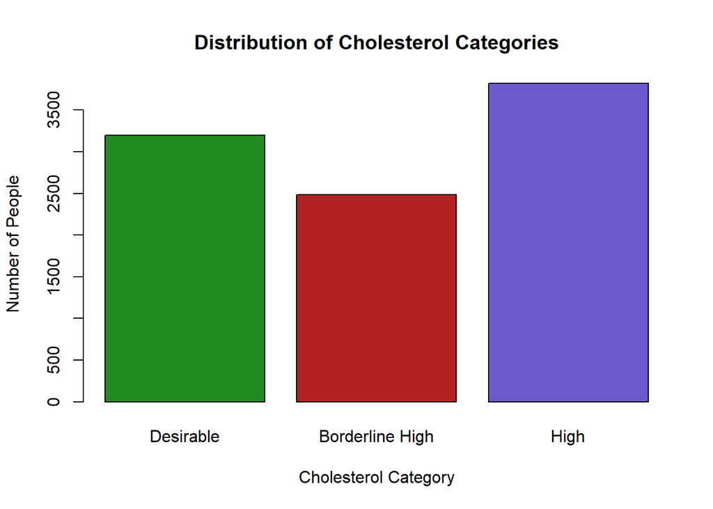

```r
barplot(cholesterol_count, main= "Distribution of Cholesterol Categories", xlab="Cholesterol Category", ylab="Number of People", col=c("forestgreen", "firebrick", "slateblue"))
```

```r
#Relationship between Cholesterol Level and a few categorical variables in this dataset

cat("By Gender")
```

```
## By Gender
```

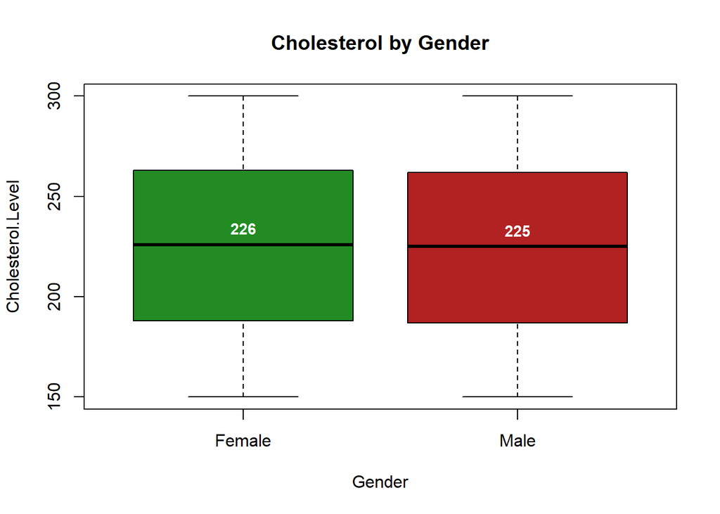

```r
boxplot(Cholesterol.Level~Gender, data=cleaned_heart_disease_data, main="Cholesterol by Gender", col=c("forestgreen", "firebrick","goldenrod3", "dodgerblue", "slateblue"))
gender_medians<- tapply(cleaned_heart_disease_data$Cholesterol.Level, cleaned_heart_disease_data$Gender, median)
text(1:length(gender_medians), gender_medians, labels=round(gender_medians,1), col="white", cex=0.9, pos=3, font=2)
```

```r
cat("By Exercise Habits")
```

```
## By Exercise Habits
```

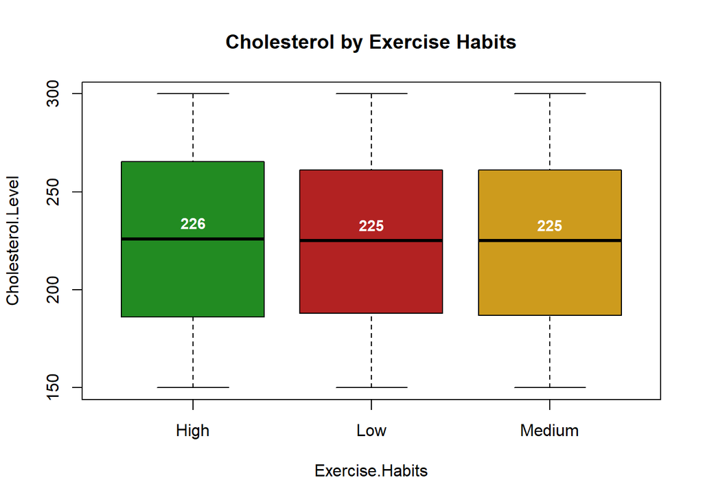

```r
boxplot(Cholesterol.Level~Exercise.Habits, data=cleaned_heart_disease_data, main="Cholesterol by Exercise Habits", col=c("forestgreen", "firebrick","goldenrod3", "dodgerblue", "slateblue"))
exercise_medians<- tapply(cleaned_heart_disease_data$Cholesterol.Level, cleaned_heart_disease_data$Exercise.Habits, median)
text(1:length(exercise_medians), exercise_medians, labels=round(exercise_medians,1), col="white", cex=0.9, pos=3, font=2)
```

```r
cat("By Smoking Habits")
```

```
## By Smoking Habits
```

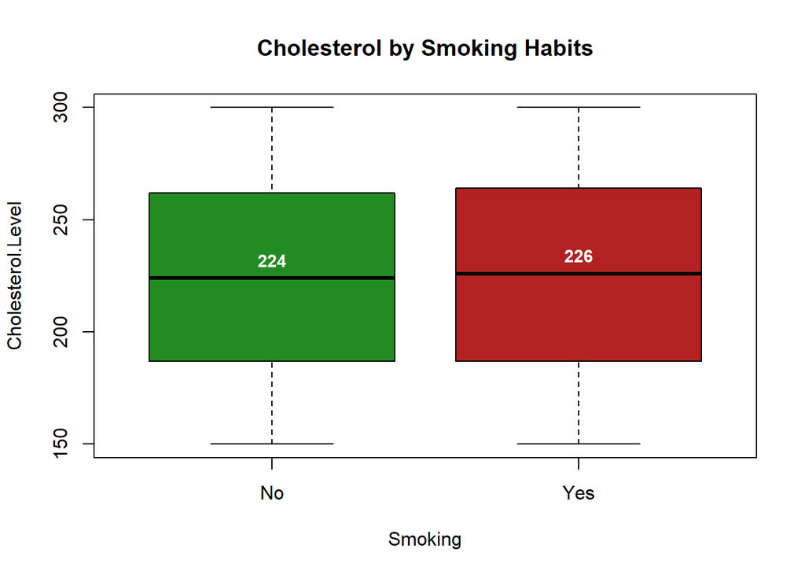

```r
boxplot(Cholesterol.Level~Smoking, data=cleaned_heart_disease_data, main="Cholesterol by Smoking Habits", col=c("forestgreen", "firebrick","goldenrod3", "dodgerblue", "slateblue"))
smoking_medians<- tapply(cleaned_heart_disease_data$Cholesterol.Level, cleaned_heart_disease_data$Smoking, median)
text(1:length(smoking_medians), smoking_medians, labels=round(smoking_medians,1), col="white", cex=0.9, pos=3, font=2)
```

```r
cat("By Heart Disease Status")
```

```
## By Heart Disease Status
```

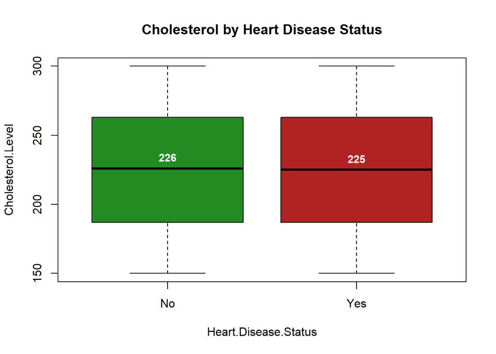

```r
boxplot(Cholesterol.Level~Heart.Disease.Status, data=cleaned_heart_disease_data, main="Cholesterol by Heart Disease Status", col=c("forestgreen", "firebrick","goldenrod3", "dodgerblue", "slateblue"))
status_medians<- tapply(cleaned_heart_disease_data$Cholesterol.Level, cleaned_heart_disease_data$Heart.Disease.Status, median)
text(1:length(status_medians), status_medians, labels=round(status_medians,1), col="white", cex=0.9, pos=3, font=2)
```

```r
# Relationship between Cholesterol and numerical/continuous variables
numerical_variables<- c("Age", "Blood.Pressure", "Cholesterol.Level", "BMI", "Sleep.Hours","Triglyceride.Level", "Fasting.Blood.Sugar", "CRP.Level", "Homocysteine.Level")
cat("Correlations with Cholesterol Level")
```

```
## Correlations with Cholesterol Level
```

```r
age_correlation <- cor(cleaned_heart_disease_data$Cholesterol.Level, cleaned_heart_disease_data$Age)
bp_correlation <- cor(cleaned_heart_disease_data$Cholesterol.Level, cleaned_heart_disease_data$Blood.Pressure)
bmi_correlation <- cor(cleaned_heart_disease_data$Cholesterol.Level, cleaned_heart_disease_data$BMI)
sleep_correlation <- cor(cleaned_heart_disease_data$Cholesterol.Level, cleaned_heart_disease_data$Sleep.Hours)
trig_correlation <- cor(cleaned_heart_disease_data$Cholesterol.Level, cleaned_heart_disease_data$Triglyceride.Level)
sugar_correlation <- cor(cleaned_heart_disease_data$Cholesterol.Level, cleaned_heart_disease_data$Fasting.Blood.Sugar)
crp_correlation <- cor(cleaned_heart_disease_data$Cholesterol.Level, cleaned_heart_disease_data$CRP.Level)
homo_correlation <- cor(cleaned_heart_disease_data$Cholesterol.Level, cleaned_heart_disease_data$Homocysteine.Level)

cat("Age:", round(age_correlation, 3), "\n")
```

```
## Age: 0.014
```

```r
cat("Blood Pressure:", round(bp_correlation, 3), "\n")
```

```
## Blood Pressure: -0.012
```

```r
cat("BMI:", round(bmi_correlation, 3), "\n")
```

```
## BMI: 0.022
```

```r
cat("Sleep Hours:", round(sleep_correlation, 3), "\n")
```

```
## Sleep Hours: 0.008
```

```r
cat("Triglyceride Level:", round(trig_correlation, 3), "\n")
```

```
## Triglyceride Level: -0.001
```

```r
cat("Fasting Blood Sugar:", round(sugar_correlation, 3), "\n")
```

```
## Fasting Blood Sugar: 0.002
```

```r
cat("CRP Level:", round(crp_correlation, 3), "\n")
```

```
## CRP Level: -0.017
```

```r
cat("Homocysteine Level:", round(homo_correlation, 3), "\n")
```

```
## Homocysteine Level: -0.005
```

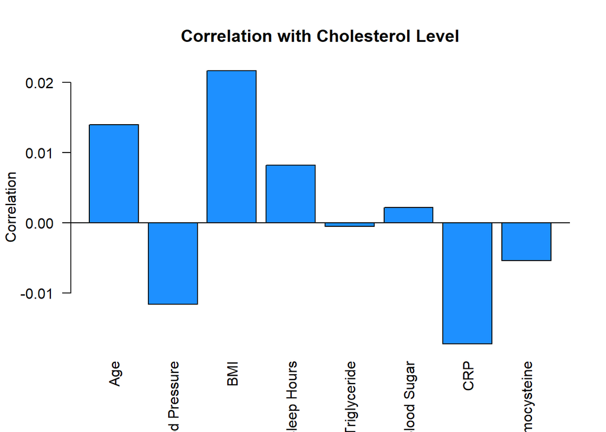

```r
num_var_names<- c("Age", "Blood Pressure", "BMI", "Sleep Hours", "Triglyceride", "Blood Sugar", "CRP", "Homocysteine")
correlation_values <- c(age_correlation, bp_correlation, bmi_correlation, sleep_correlation, trig_correlation, sugar_correlation, crp_correlation, homo_correlation)

# Barplot
barplot(correlation_values, names.arg = num_var_names, main = "Correlation with Cholesterol Level", ylab = "Correlation", col = "dodgerblue", las = 2)
abline(h = 0)
```

3. Hypothesis Testing : t-tests(2 groupings) and anova(more than 2 groupings) | Categorical Variables

```r
two_valued_var<- c("Gender", "Smoking", "Family.Heart.Disease", "Diabetes", "High.Blood.Pressure", "Low.HDL.Cholesterol", "High.LDL.Cholesterol", "Heart.Disease.Status")
#Gender and Cholesterol Levels
gender_test<- t.test(Cholesterol.Level~Gender, data=cleaned_heart_disease_data)
cat("Gender and Cholesterol t-test:\n")
```

```
## Gender and Cholesterol t-test:
```

```r
print(gender_test)
```

```
##
##  Welch Two Sample t-test
##
## data:  Cholesterol.Level by Gender
## t = 1.0858, df = 9497.3, p-value = 0.2776
## alternative hypothesis: true difference in means between group Female and group Male is not equal to 0
## 95 percent confidence interval:
##  -0.7825208  2.7259276
## sample estimates:
## mean in group Female   mean in group Male
##             225.7814             224.8097
```

```r
#Smoking and Cholesterol Levels
smoking_test <- t.test(Cholesterol.Level ~ Smoking, data = cleaned_heart_disease_data)
cat("\nSmoking and Cholesterol t-test:\n")
```

```
##
## Smoking and Cholesterol t-test:
```

```r
print(smoking_test)
```

```
##
##  Welch Two Sample t-test
##
## data:  Cholesterol.Level by Smoking
## t = -0.82376, df = 9475.5, p-value = 0.4101
## alternative hypothesis: true difference in means between group No and group Yes is not equal to 0
## 95 percent confidence interval:
##  -2.492124  1.017319
## sample estimates:
##  mean in group No mean in group Yes
##          224.9172          225.6546
```

```r
#Family Heart Disease and Cholesterol Levels
fam_heart_test <- t.test(Cholesterol.Level ~ Family.Heart.Disease, data = cleaned_heart_disease_data)
cat("\nFamily Heart Disease and Cholesterol t-test:\n")
```

```
##
## Family Heart Disease and Cholesterol t-test:
```

```r
print(fam_heart_test)
```

```
##
##  Welch Two Sample t-test
##
## data:  Cholesterol.Level by Family.Heart.Disease
## t = 0.90324, df = 9498, p-value = 0.3664
## alternative hypothesis: true difference in means between group No and group Yes is not equal to 0
## 95 percent confidence interval:
##  -0.9459024  2.5625333
## sample estimates:
##  mean in group No mean in group Yes
##          225.6977          224.8894
```

```r
#Diabetes and Cholesterol Levels
diabetes_test <- t.test(Cholesterol.Level ~ Diabetes, data = cleaned_heart_disease_data)
cat("\nDiabetes and Cholesterol t-test:\n")
```

```
##
## Diabetes and Cholesterol t-test:
```

```r
print(diabetes_test)
```

```
##
##  Welch Two Sample t-test
##
## data:  Cholesterol.Level by Diabetes
## t = -0.30906, df = 9494.5, p-value = 0.7573
## alternative hypothesis: true difference in means between group No and group Yes is not equal to 0
## 95 percent confidence interval:
##  -2.031035  1.477805
## sample estimates:
##  mean in group No mean in group Yes
##          225.1584          225.4350
```

```r
#High BP and Cholesterol Levels
BP_test <- t.test(Cholesterol.Level ~ High.Blood.Pressure, data = cleaned_heart_disease_data)
cat("\nHigh Blood Pressure and Cholesterol t-test:\n")
```

```
##
## High Blood Pressure and Cholesterol t-test:
```

```r
print(BP_test)
```

```
##
##  Welch Two Sample t-test
##
## data:  Cholesterol.Level by High.Blood.Pressure
## t = 1.0076, df = 9497.4, p-value = 0.3137
## alternative hypothesis: true difference in means between group No and group Yes is not equal to 0
## 95 percent confidence interval:
##  -0.8525429  2.6559728
## sample estimates:
##  mean in group No mean in group Yes
##          225.7470          224.8453
```

```r
#Low HDL Cholesterol and Cholesterol Levels
low_hdl_test <- t.test(Cholesterol.Level ~ Low.HDL.Cholesterol, data = cleaned_heart_disease_data)
cat("\nLow HDL and Cholesterol t-test:\n")
```

```
##
## Low HDL and Cholesterol t-test:
```

```r
print(low_hdl_test)
```

```
##
##  Welch Two Sample t-test
##
## data:  Cholesterol.Level by Low.HDL.Cholesterol
## t = 0.62054, df = 9498, p-value = 0.5349
## alternative hypothesis: true difference in means between group No and group Yes is not equal to 0
## 95 percent confidence interval:
##  -1.198904  2.309576
## sample estimates:
##  mean in group No mean in group Yes
##          225.5746          225.0193
```

```r
#High LDL Cholesterol and Cholesterol Levels
high_ldl_test <- t.test(Cholesterol.Level ~ High.LDL.Cholesterol, data = cleaned_heart_disease_data)
cat("\nHigh LDL and Cholesterol t-test:\n")
```

```
##
## High LDL and Cholesterol t-test:
```

```r
print(high_ldl_test)
```

```
##
##  Welch Two Sample t-test
##
## data:  Cholesterol.Level by High.LDL.Cholesterol
## t = 0.05104, df = 9492.8, p-value = 0.9593
## alternative hypothesis: true difference in means between group No and group Yes is not equal to 0
## 95 percent confidence interval:
##  -1.708748  1.800112
## sample estimates:
##  mean in group No mean in group Yes
##          225.3180          225.2723
```

```r
#Heart Disease Status and Cholesterol Levels
heart_test <- t.test(Cholesterol.Level ~ Heart.Disease.Status, data = cleaned_heart_disease_data)
cat("\nHeart Disease Status and Cholesterol t-test:\n")
```

```
##
## Heart Disease Status and Cholesterol t-test:
```

```r
print(heart_test)
```

```
##
##  Welch Two Sample t-test
##
## data:  Cholesterol.Level by Heart.Disease.Status
## t = 0.051033, df = 2951.2, p-value = 0.9593
## alternative hypothesis: true difference in means between group No and group Yes is not equal to 0
## 95 percent confidence interval:
##  -2.121819  2.235220
## sample estimates:
##  mean in group No mean in group Yes
##          225.3068          225.2501
```

```r
multi_valued_var<- c("Exercise.Habits", "Alcohol.Consumption", "Stress.Level", "Sugar.Consumption")

exercise_anova <- aov(Cholesterol.Level ~ Exercise.Habits, data = cleaned_heart_disease_data)
cat("\nExercise Habits and Cholesterol ANOVA:\n")
```

```
##
## Exercise Habits and Cholesterol ANOVA:
```

```r
print(summary(exercise_anova))
```

```
##                   Df   Sum Sq Mean Sq F value Pr(>F)
## Exercise.Habits    2      653   326.3   0.172  0.842
## Residuals       9497 18067535  1902.4
```

```r
alcohol_anova <- aov(Cholesterol.Level ~ Alcohol.Consumption, data = cleaned_heart_disease_data)
cat("\nAlcohol Consumption and Cholesterol ANOVA:\n")
```

```
##
## Alcohol Consumption and Cholesterol ANOVA:
```

```r
print(summary(alcohol_anova))
```

```
##                       Df   Sum Sq Mean Sq F value Pr(>F)
## Alcohol.Consumption    3    11294    3765    1.98  0.115
## Residuals           9496 18056893    1902
```

```r
stress_anova <- aov(Cholesterol.Level ~ Stress.Level, data = cleaned_heart_disease_data)
cat("\nStress Level and Cholesterol ANOVA:\n")
```

```
##
## Stress Level and Cholesterol ANOVA:
```

```r
print(summary(stress_anova))
```

```
##                Df   Sum Sq Mean Sq F value Pr(>F)
## Stress.Level    2     4139    2070   1.088  0.337
## Residuals    9497 18064048    1902
```

```r
sugar_anova <- aov(Cholesterol.Level ~ Sugar.Consumption, data = cleaned_heart_disease_data)
cat("\nSugar Consumption and Cholesterol ANOVA:\n")
```

```
##
## Sugar Consumption and Cholesterol ANOVA:
```